# Bulk RNA-Seq analysis

Elisabeth F. Heuston

Analysis of mouse single cell hematopoietic populations - Bulk RNA-Seq differential expression anaysis

This notebook contains the R workflow to analyze bulk RNS-Seq data and pertains to: * Figure 6A * Supplemental Figure 7A

Raw data for this publication are available from the GEO Project GSE168260 at https://www.ncbi.nlm.nih.gov/geo/query/acc.cgi?acc=GSE168260  
Raw data previously published in Heuston et al., 2018, is available at www.usevision.org

## Principal component analysis of hematopoietic RNA-Seq profiles

Transcriptional comparison of 11 populations. Each sample was sequenced in duplicate.

- LSK
- CMP
- GMP
- CFU-E
- CFU-Mk
- EB
- MK
- C10 (CMP subpopulation from cluster 10)
- C11 (CMP subpopulation from cluster 11)
- C17 (CMP subpopulation from cluster 17)
- C3 (CMP subpopulation from cluster 3)

Transcriptome alignments were performed in STAR, and read estimation performed in RSEM.

### Load libraries

```r
library(tximport)
library(TxDb.Mmusculus.UCSC.mm10.knownGene)
library(edgeR)
library(colorRamps)
library(org.Mm.eg.db)
library(ggplot2)
library(scatterplot3d)
library(mouseSingleCell)
```

### Comprison of all hematopoietic populations

Start by comparing previously isolated bulk RNA and prospectively isolated CMP subpopulations #### Import read estimation (RSEM) files The `mouseSingleCell` library contains code, functions, and data to reproduce the analyses presented in the manuscript  
First generate a list of the files to be imported

```r
file_list <- list.files(pattern = 'genes.results', ignore.case = FALSE, recursive = FALSE, include.dirs = FALSE)
names(file_list) <- lapply(file_list, function(x) gsub('.genes.results', '', x))
file_list
```

```
                  C10_R1                   C10_R2                   C11_R1                   C11_R2                   C17_R1                   C17_R2
  "C10_R1.genes.results"   "C10_R2.genes.results"   "C11_R1.genes.results"   "C11_R2.genes.results"   "C17_R1.genes.results"   "C17_R2.genes.results"
                   C3_R1                    C3_R2                  CFUE833                  CFUE834                 CFUMK747                 CFUMK748
   "C3_R1.genes.results"    "C3_R2.genes.results"  "CFUE833.genes.results"  "CFUE834.genes.results" "CFUMK747.genes.results" "CFUMK748.genes.results"
                  CMP443                   CMP448                   ERY835                   ERY836                   GMP444                   GMP449
  "CMP443.genes.results"   "CMP448.genes.results"   "ERY835.genes.results"   "ERY836.genes.results"   "GMP444.genes.results"   "GMP449.genes.results"
                  LSK612                   LSK613                    MK749                    MK750
  "LSK612.genes.results"   "LSK613.genes.results"    "MK749.genes.results"    "MK750.genes.results"
```

Now import the files using `tximport` to identify the counts columns

```r
mstxi <- tximport::tximport(files = file_list, type = 'rsem', txIn = FALSE, txOut = FALSE, geneIdCol = 3)
```

```
reading in files with read_tsv
1 2 3 4 5 6 7 8 9 10 11 12 13 14 15 16 17 18 19 20 21 22
```

```r
cts <- mstxi$counts
colnames(cts)
```

```
 [1] "C10_R1"   "C10_R2"   "C11_R1"   "C11_R2"   "C17_R1"   "C17_R2"   "C3_R1"    "C3_R2"    "CFUE833"  "CFUE834"  "CFUMK747" "CFUMK748" "CMP443"   "CMP448"   "ERY835"
[16] "ERY836"   "GMP444"   "GMP449"   "LSK612"   "LSK613"   "MK749"    "MK750"
```

#### Generate DGE object and QC

Set CMP as reference sample and generate DGE object

```r
dgelist_groups <- factor(c('C10', 'C10', 'C11', 'C11', 'C17', 'C17', 'C3s', 'C3s', 'CFUE', 'CFUE', 'CFUMK', 'CFUMK', 'CMP', 'CMP', 'ERY', 'ERY', 'GMP', 'GMP', 'LSK', 'LSK', 'MK', 'MK'))
dgelist_groups <- relevel(dgelist_groups, ref = "CMP")
dgelist <- DGEList(counts = cts, group = dgelist_groups)
apply(dgelist$counts, 2, sum)
```

```
  C10_R1   C10_R2   C11_R1   C11_R2   C17_R1   C17_R2    C3_R1    C3_R2  CFUE833  CFUE834 CFUMK747 CFUMK748   CMP443   CMP448   ERY835   ERY836   GMP444   GMP449
20632005 15017611 12753193  7237587 12893841 12073092 19594630 10318447 14808711 13482226 73167189 67678024 31763431 28668883 13298363 16777589 44905308 38438583
  LSK612   LSK613    MK749    MK750
39815156 28754331 70018579 63439228
```

Keep only genes that have a CPM of 5 in at least 2 samples

```r
keep <- rowSums(cpm(dgelist) > 5) >=2
dgelist <- dgelist[keep,]
```

#### ID conversion

Annotate with gene symbols. Note that mouseIDTable is included to permit offline analysis. For up-to-date annotations, use `mouseSingleCell::Mouse2Human_idconversion`, which accesses information directly from ensembl using biomaRt (BioConductor).

```r
mouseIDTable <- Mouse2Human(MouseGenes = mouseIDTable$MGI)

# Convert symbol column ot dgelist
symbol = rownames(dgelist$counts)
dgelist$genes <- data.frame(Symbol = symbol)

# Add Hs homologue to dgelist
HsHmlg <- with(mouseIDTable, mouseIDTable$HGNC[match(row.names(dgelist), mouseIDTable$MGI)])
dgelist$genes$HsHmlg <- HsHmlg
dgelist$genes$HsHmlg[dgelist$genes$HsHmlg == ""] <- NA

# Convert row names to entrez gene ID
entrezid <- with(mouseIDTable, mouseIDTable$Entrez.Gene_ID[match(row.names(dgelist), mouseIDTable$MGI)])
entrezid[is.na(entrezid)] <- 'not_mapped'
rownames(dgelist$counts) <- entrezid
dgelist <- dgelist[!(row.names(dgelist) %in% 'not_mapped'), ] # get rid of unmapped entrez ids
```

#### Calculate library size

Perform library correction with `DESeq2::rlog`

```r
dgelist$samples$lib.size <- colSums(dgelist$counts)
dgelist <- calcNormFactors(dgelist)
cts <- DESeq2::rlog(round(mstxi$counts), blind = TRUE)
```

#### Principal component analysis

prcomp PCA

```r
pca.cts <- prcomp(t(cts))
scores=data.frame(pca.cts$x)
cols=ncol(scores)
scores=data.frame(scores,dgelist_groups)
colnames(scores)[cols+1]="cell"
colors <- c('darkviolet', 'cyan2', 'sienna1', 'seagreen3', 'brown4', 'violetred2', 'steelblue2', 'red1', 'darkgreen', 'black', 'royalblue')
points <- c(rep(19, 26))
```

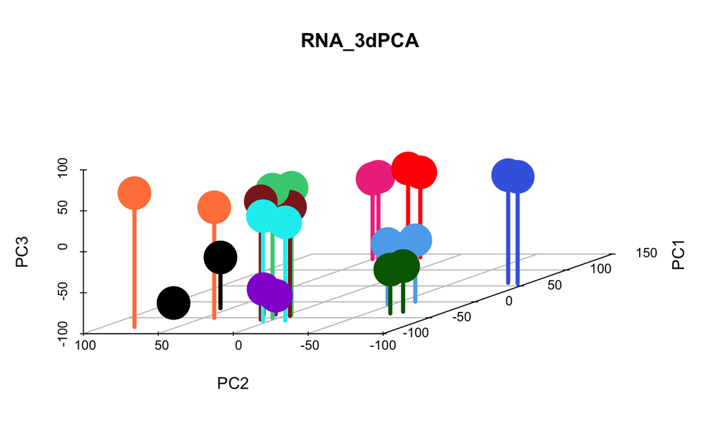

```r
scatterplot3d(scores[,1:3],
                            color = colors[dgelist_groups],
                            pch = points[dgelist_groups],
                            lwd = 4,
                            cex.symbols = 4,
                            grid = T, box = F,
                            type = 'h',
                            xlab = 'PC1', ylab = 'PC2', zlab = 'PC3',
                            main = 'RNA_3dPCA',
                            angle = 215)
```

```r
# legend("topright", legend = levels(dgelist_groups), pch = points, col = colors, ncol = 1, pt.cex = 0.5, cex = 0.5)
```

#### Differential gene expression

To determine if CMP subpopulations have expression profiles similar to progenitor or lineage-restricted populations, generate enrichment gene sets for each  
Create the design matrix for downstream (do not set CMP as intercept)

```r
designMat <- model.matrix(~ 0 + dgelist$samples$group)
colnames(designMat) <- levels(dgelist$samples$group)
designMat

# Apply GLM dispersion ------------------------------------------------------------

dgelist <- estimateGLMCommonDisp(dgelist, designMat)
dgelist <- estimateGLMTrendedDisp(dgelist, designMat, method = 'bin.spline')
dgelist <- estimateGLMTagwiseDisp(dgelist, designMat)
fit <- glmFit(dgelist, designMat)
```

Generate LSK, CMP, GMP, EB, MK gene sets

```r
bulk.contrasts <- makeContrasts(ERYvCMP = ERY - CMP,
                                                                ERYvGMP = ERY - GMP,
                                                                ERYvLSK = ERY - LSK,
                                                                ERYvMK = ERY - MK,

                                                                GMPvCMP = GMP - CMP,
                                                                GMPvERY = GMP - ERY,
                                                                GMPvLSK = GMP - LSK,
                                                                GMPvMK = GMP - MK,

                                                                LSKvCMP = LSK - CMP,
                                                                LSKvGMP = LSK - GMP,
                                                                LSKvERY = LSK - ERY,
                                                                LSKvMK = LSK - MK,

                                                                MKvCMP = MK - CMP,
                                                                MKvGMP = MK - GMP,
                                                                MKvLSK = MK - LSK,
                                                                MKvERY = MK - ERY,

                                                                CMPvERY = CMP - ERY,
                                                                CMPvGMP = CMP - GMP,
                                                                CMPvLSK = CMP - LSK,
                                                                CMPvMK = CMP - MK,

                                                                levels = designMat)

bulk_population_expression_sets(bulk.contrasts, file.name = "LSK_CMP_GMP_EB_MK.gmt")
```

## Compare subpopulations to CMP in isolation

We want a list of genes upregulated in CMP subpopulations compared to CMP, regardless of their relative expression level in other populations. Therefore repeat DGE using only CMP subpopulation samples and set CMP as intercept

```r
file_list <- c(list.files(pattern = '_R', ignore.case = FALSE, recursive = FALSE, include.dirs = FALSE), list.files(pattern = '^CMP', recursive = FALSE, include.dirs = FALSE))
names(file_list) <- lapply(file_list, function(x) gsub('.genes.results', '', x))
mstxi <- tximport(files = file_list, type = 'rsem', txIn = FALSE, txOut = FALSE, geneIdCol = 3)
cts <- mstxi$counts

# Set reference sample
dgelist_groups <- factor(c('C10', 'C10', 'C11', 'C11', 'C17', 'C17', 'C3s', 'C3s', 'CMP', 'CMP'))
dgelist_groups <- relevel(dgelist_groups, ref = "CMP")
dgelist <- DGEList(counts = cts, group = dgelist_groups)
keep <- rowSums(cpm(dgelist) > 5) >=2
dgelist <- dgelist[keep,]
symbol = rownames(dgelist$counts)
dgelist$genes <- data.frame(Symbol = symbol)

# Add Hs homologue to dgelist
HsHmlg <- with(mouseIDTable, mouseIDTable$HGNC[match(row.names(dgelist), mouseIDTable$MGI)])
dgelist$genes$HsHmlg <- HsHmlg
dgelist$genes$HsHmlg[dgelist$genes$HsHmlg == ""] <- NA
entrezid <- with(mouseIDTable, mouseIDTable$Entrez.Gene_ID[match(row.names(dgelist), mouseIDTable$MGI)])
entrezid[is.na(entrezid)] <- 'not_mapped'
rownames(dgelist$counts) <- entrezid
dgelist <- dgelist[!(row.names(dgelist) %in% 'not_mapped'), ] # get rid of unmapped entrez ids
```

Calculate library size

```r
dgelist$samples$lib.size <- colSums(dgelist$counts)
dgelist <- calcNormFactors(dgelist)
```

Estimate dispersion **with** CMP defined as intercept

```r
designMat <- model.matrix(~dgelist$samples$group)
colnames(designMat) <- c('(Intercept)', levels(dgelist$samples$group)[2:length(levels(dgelist$samples$group))])

# Apply GLM dispersion ------------------------------------------------------------

dgelist <- estimateGLMCommonDisp(dgelist, designMat)
dgelist <- estimateGLMTrendedDisp(dgelist, designMat, method = 'bin.spline')
dgelist <- estimateGLMTagwiseDisp(dgelist, designMat)

# GLM differential expression testing ------------------------------------------------------------
fit <- glmFit(dgelist, designMat)
```

Create ranked gene files for CMP subpopulations

```r
lrt.c10 <-  glmLRT(fit, coef = 2)
gsea_ranking(lrt.c10, 'c10vCMP_2FC')

lrt.c11 <-  glmLRT(fit, coef = 3)
gsea_ranking(lrt.c11, 'c11vCMP_2FC')

lrt.c17 <-  glmLRT(fit, coef = 4)
gsea_ranking(lrt.c17, 'c17vCMP_2FC')

lrt.c3s <-  glmLRT(fit, coef = 5)
gsea_ranking(lrt.c3s, 'c3svCMP_2FC')
```

Perform [GSEA analysis](https://github.com/efheuston/CMPSubpopulation_dataAnalysis/blob/main/BulkRNA-SeqAnalysis.ipynb) to find (de)enrichment of genes differentially expressed in CMP subpopulations compared to LSK, CMP, GMP, EB, and MK.